# 3_5 Zygotic genes - First expression

Manuel Jara-Espejo

# 1 Introduction

This notebook describes the identification of zygotic transcripts detected using the *First Expression* method. Briefly, zygotic genes were defined as those: * Not maternally provided * Significantly upregulated in each stage, usign as 0-9 hrs sample as reference timepoint

# 2 Detection of zygotic genes using PolyA data

## 2.1 Create sample files table

```r
knitr::opts_chunk$set(message=F,warning=F,echo=T)
#load libraries
library(tidyr)
library(dplyr)
library(ggplot2)
library(reshape2)
library(ggpubr)
library(tibble)
library(pheatmap)
library(ggplotify)
library(RColorBrewer)

#Create sample files table
sampleFiles <- c('S1','S4','S7','S2','S5','S8','P121','P122','P123','P141','P142','P143','P161','P162','P201','P202','P241','P242','P481','P482','S3','S6','S9')
stage <- factor(c(rep(c('0-9','11','12','13-14'),each=3),rep(c('16','20','24',"48"),each=2),rep("24-60",3)),levels=c('0-9','11','12','13-14','16','20','24',"48","24-60"))

sampleTable <- data.frame(sampleName = sampleFiles,
                          condition = stage) %>% filter(sampleName != "S5", condition != "48")
rownames(sampleTable) <- sampleTable$sampleName
sampleTable
```

|  | sampleName | condition |
| --- | --- | --- |
| S1 | S1 | 0-9 |
| S4 | S4 | 0-9 |
| S7 | S7 | 0-9 |
| S2 | S2 | 11 |
| S8 | S8 | 11 |
| P121 | P121 | 12 |
| P122 | P122 | 12 |
| P123 | P123 | 12 |
| P141 | P141 | 13-14 |
| P142 | P142 | 13-14 |

[output cut: 10 more lines]

## 2.2 Load counts data

```r
exon_polyA_counts= read.table("/drives/ssd1/manuel/phaw/2022_analysis/mzt_analysis/embryo_exonCounts_polyA.txt",header = T,sep = "\t",stringsAsFactors = F)
colnames(exon_polyA_counts) = sub(".bam", "", colnames(exon_polyA_counts))
exon_polyA_counts = exon_polyA_counts[,unfactor(sampleTable$sampleName)]
exon_polyA_counts %>% head()
```

|  | S1 | S4 | S7 | S2 | S8 | P121 | P122 | P123 | P141 | P142 | P143 | P161 | P162 | P201 | P202 | P241 | P242 | S3 | S6 | S9 |
| --- | --- | --- | --- | --- | --- | --- | --- | --- | --- | --- | --- | --- | --- | --- | --- | --- | --- | --- | --- | --- |
| MSTRG.18409 | 50 | 53 | 53 | 107 | 94 | 113 | 107 | 84 | 101 | 115 | 88 | 77 | 52 | 45 | 46 | 36 | 27 | 21 | 27 | 5 |
| MSTRG.18410 | 16 | 14 | 14 | 4 | 8 | 2 | 5 | 7 | 4 | 1 | 3 | 0 | 2 | 5 | 3 | 4 | 1 | 9 | 7 | 5 |
| MSTRG.18412 | 20 | 11 | 12 | 17 | 18 | 16 | 10 | 15 | 16 | 13 | 10 | 10 | 31 | 19 | 43 | 22 | 23 | 13 | 13 | 13 |
| MSTRG.18413 | 4712 | 3426 | 2574 | 2703 | 2494 | 2338 | 2438 | 1992 | 2760 | 2858 | 2514 | 2115 | 1852 | 1068 | 1878 | 1193 | 1056 | 826 | 918 | 542 |
| MSTRG.18418 | 1 | 0 | 0 | 0 | 0 | 0 | 0 | 0 | 0 | 0 | 0 | 0 | 0 | 0 | 0 | 0 | 0 | 0 | 0 | 1 |
| MSTRG.18420 | 0 | 0 | 0 | 2 | 0 | 0 | 0 | 1 | 0 | 0 | 0 | 0 | 1 | 2 | 3 | 1 | 0 | 0 | 0 | 0 |

## 2.3 Get genes maternally absent and expressed in at least one of the posterior stages

```r
up_11hs <- exon_polyA_counts %>% filter(across(c(S1, S7), ~ . < 5 ), across(c(S2, S8), ~ . > 20 )) %>% rownames_to_column(var = "gene_id") %>% pull(gene_id)
up_12hs <- exon_polyA_counts  %>% filter(across(c(S1, S7), ~ . < 5 ), across(c(P121, P123), ~ . > 20 )) %>% rownames_to_column(var = "gene_id") %>% pull(gene_id)
up_14hs <- exon_polyA_counts %>% filter(across(c(S1, S7), ~ . < 5 ), across(c(P141, P143), ~ . > 20 )) %>% rownames_to_column(var = "gene_id") %>% pull(gene_id)
up_16hs <- exon_polyA_counts %>% filter(across(c(S1, S7), ~ . < 5 ), across(c(P161, P162), ~ . > 20 )) %>% rownames_to_column(var = "gene_id") %>% pull(gene_id)
up_20hs <- exon_polyA_counts %>% filter(across(c(S1, S7), ~ . < 5 ), across(c(P201, P202), ~ . > 20 )) %>% rownames_to_column(var = "gene_id") %>% pull(gene_id)
up_24hs <- exon_polyA_counts  %>% filter(across(c(S1, S7), ~ . < 5 ), across(c(P241, P242), ~ . > 20 )) %>% rownames_to_column(var = "gene_id") %>% pull(gene_id)
up_24_60hs <- exon_polyA_counts  %>% filter(across(c(S1, S7), ~ . < 5 ), across(c(S3, S9), ~ . > 20 )) %>% rownames_to_column(var = "gene_id") %>% pull(gene_id)
```

## 2.4 Number of genes maternally absent and expressed in each posterior stage

```r
up_11hs %>% length()
```

```
[1] 0
```

```r
up_12hs %>% length()
```

```
[1] 1
```

```r
up_14hs %>% length()
```

```
[1] 19
```

```r
up_16hs %>% length()
```

```
[1] 527
```

```r
up_20hs %>% length()
```

```
[1] 682
```

```r
up_24hs %>% length()
```

```
[1] 732
```

```r
up_24_60hs %>% length()
```

```
[1] 848
```

## 2.5 Test for significant upregulation between 9hrs and each next stage

```r
comparisons <- list(c('0-9','11'),c('0-9','12'),c('0-9','13-14'),c('0-9','16'),
                    c('0-9','20'),c('0-9','24'),c('0-9','24-60'))
replicates_n <- list(c(3,2),c(3,3),c(3,3),c(3,2),c(3,2),c(3,2),c(3,3))
genes_up2test <- list(up_11hs,up_12hs,up_14hs,up_16hs,up_20hs,up_24hs,up_24_60hs)
firstExp_polya <-  list()

for (i in 1:length(comparisons)) {
  temp_df <- sampleTable %>% filter(condition %in% comparisons[[i]]) %>%
                                      mutate(condition = factor(rep(comparisons[[i]],times=replicates_n[[i]]),levels=comparisons[[i]]))

#Run Differential expressiona analysis - Load count matrix into DeSEQ
dds <- DESeqDataSetFromMatrix(countData = exon_polyA_counts[,unfactor(temp_df$sampleName)],
                       colData = temp_df,design = ~ condition)
keep <- rowSums(counts(dds)) >= 1 #Filtered out data
dds <- dds[keep,]

dds_table = DESeq(dds) #Perform Diff expression test
comp_table <- results(dds_table)

#Filtering results
dds_table_filtered <- comp_table %>% data.frame() %>% filter(complete.cases(.)) %>% filter( padj < 0.05 & log2FoldChange > 0)

# Keep only up-regulated genes matching first filter criteria (no maternal and detected in next stages)
firstExp <- dds_table_filtered %>% rownames_to_column(var = "gene_id") %>%
  filter(gene_id %in% genes_up2test[[i]]) %>% pull(gene_id)

#Store upregulated genes in list
firstExp_polya[[i]] <- firstExp

rm(temp_df)
   }
```

### 2.5.1 Number of zygotic genes per stage

```r
names(firstExp_polya)  <- c('0-9_11','0-9_12','0-9_13-14','0-9_16','0-9_20','0-9_24','0-9_24-60')
firstExp_polya %>% lengths()
```

```
   0-9_11    0-9_12 0-9_13-14    0-9_16    0-9_20    0-9_24 0-9_24-60
        0         1        19       527       682       732       848
```

# 3 Detection of zygotic genes using TOTAL RNA-seq data

```r
#Create sample files table
sampleFiles <- c('S1','S4','S7','S2','S5','S8','P121','P122','P123','P141','P142','P143','P161','P162','P201','P202','P241','P242','P481','P482','S3','S6','S9')
sampleFiles <- gsub("S|P","T",sampleFiles)
stage <- factor(c(rep(c('0-9','11','12','13-14'),each=3),rep(c('16','20','24',"48"),each=2),rep("24-60",3)),levels=c('0-9','11','12','13-14','16','20','24',"48","24-60"))

sampleTable <- data.frame(sampleName = sampleFiles, condition = stage) %>% filter(sampleName != "T5",condition != "48")
rownames(sampleTable) <- sampleTable$sampleName
sampleTable
```

|  | sampleName | condition |
| --- | --- | --- |
| T1 | T1 | 0-9 |
| T4 | T4 | 0-9 |
| T7 | T7 | 0-9 |
| T2 | T2 | 11 |
| T8 | T8 | 11 |
| T121 | T121 | 12 |
| T122 | T122 | 12 |
| T123 | T123 | 12 |
| T141 | T141 | 13-14 |
| T142 | T142 | 13-14 |

[output cut: 10 more lines]

```r
NA
```

## 3.1 Load counts data

```r
exon_total_counts= read.table("/drives/ssd1/manuel/phaw/2022_analysis/mzt_analysis/embryo_exonCounts_total.txt",header = T,sep = "\t",stringsAsFactors = F)
colnames(exon_total_counts) <- gsub(".Mixed","",sub(".bam", "", colnames(exon_total_counts)))
exon_total_counts <- exon_total_counts[,unfactor(sampleTable$sampleName)]
exon_total_counts %>% head()
```

|  | T1 | T4 | T7 | T2 | T8 | T121 | T122 | T123 | T141 | T142 | T143 | T161 | T162 | T201 | T202 | T241 | T242 | T3 | T6 | T9 |
| --- | --- | --- | --- | --- | --- | --- | --- | --- | --- | --- | --- | --- | --- | --- | --- | --- | --- | --- | --- | --- |
| MSTRG.18409 | 190 | 208 | 152 | 166 | 92 | 104 | 35 | 98 | 81 | 90 | 76 | 39 | 27 | 24 | 26 | 15 | 16 | 10 | 13 | 5 |
| MSTRG.18410 | 9 | 22 | 21 | 11 | 16 | 3 | 6 | 4 | 10 | 11 | 4 | 5 | 3 | 6 | 9 | 2 | 5 | 14 | 8 | 4 |
| MSTRG.18412 | 23 | 27 | 40 | 34 | 22 | 23 | 21 | 10 | 9 | 34 | 8 | 9 | 1 | 10 | 15 | 19 | 5 | 10 | 8 | 10 |
| MSTRG.18413 | 1530 | 1619 | 1182 | 1311 | 952 | 1693 | 568 | 1030 | 1699 | 1739 | 1521 | 1594 | 1418 | 1207 | 1408 | 1589 | 1534 | 454 | 713 | 568 |
| MSTRG.18418 | 4 | 1 | 0 | 0 | 0 | 0 | 3 | 0 | 0 | 0 | 0 | 0 | 0 | 0 | 0 | 0 | 0 | 0 | 1 | 0 |
| MSTRG.18420 | 0 | 0 | 1 | 0 | 0 | 1 | 0 | 0 | 0 | 0 | 1 | 8 | 7 | 2 | 1 | 4 | 10 | 3 | 2 | 2 |

## 3.2 Get genes maternally absent and expressed in at least one of the posterior stages

```r
up_11hs <- exon_total_counts %>% filter(across(c(T1, T7), ~ . < 5 ), across(c(T2, T8), ~ . > 20 )) %>% rownames_to_column(var = "gene_id") %>% pull(gene_id)
up_12hs <- exon_total_counts %>% filter(across(c(T1, T7), ~ . < 5 ), across(c(T121, T123), ~ . > 20 )) %>% rownames_to_column(var = "gene_id") %>% pull(gene_id)
up_14hs <- exon_total_counts %>% filter(across(c(T1, T7), ~ . < 5 ), across(c(T141, T143), ~ . > 20 )) %>% rownames_to_column(var = "gene_id") %>% pull(gene_id)
up_16hs <- exon_total_counts %>% filter(across(c(T1, T7), ~ . < 5 ), across(c(T161, T162), ~ . > 20 )) %>% rownames_to_column(var = "gene_id") %>% pull(gene_id)
up_20hs <- exon_total_counts %>% filter(across(c(T1, T7), ~ . < 5 ), across(c(T201, T202), ~ . > 20 )) %>% rownames_to_column(var = "gene_id") %>% pull(gene_id)
up_24hs <- exon_total_counts %>% filter(across(c(T1, T7), ~ . < 5 ), across(c(T241, T242), ~ . > 20 )) %>% rownames_to_column(var = "gene_id") %>% pull(gene_id)
up_24_60hs <- exon_total_counts %>% filter(across(c(T1, T7), ~ . < 5 ), across(c(T3, T9), ~ . > 20 )) %>% rownames_to_column(var = "gene_id") %>% pull(gene_id)
```

## 3.3 Number of genes maternally absent and expressed in each posterior stage

```r
up_11hs %>% length()
```

```
[1] 1
```

```r
up_12hs %>% length()
```

```
[1] 39
```

```r
up_14hs %>% length()
```

```
[1] 126
```

```r
up_16hs %>% length()
```

```
[1] 612
```

```r
up_20hs %>% length()
```

```
[1] 655
```

```r
up_24hs %>% length()
```

```
[1] 749
```

```r
up_24_60hs %>% length()
```

```
[1] 821
```

## 3.4 Test for significant upregulation between 9hrs and each next stage - Total RNA-seq

```r
comparisons <- list(c('0-9','11'),c('0-9','12'),c('0-9','13-14'),c('0-9','16'),
                    c('0-9','20'),c('0-9','24'),c('0-9','24-60'))
replicates_n <- list(c(3,2),c(3,3),c(3,3),c(3,2),c(3,2),c(3,2),c(3,3))
genes_up2test <- list(up_11hs,up_12hs,up_14hs,up_16hs,up_20hs,up_24hs,up_24_60hs)
firstExp_total <-  list()

for (i in 1:length(comparisons)) {
  temp_df <- sampleTable %>% filter(condition %in% comparisons[[i]]) %>%
                                      mutate(condition = factor(rep(comparisons[[i]],times=replicates_n[[i]]),levels=comparisons[[i]]))

#Run Differential expressiona analysis - Load count matrix into DeSEQ
dds <- DESeqDataSetFromMatrix(countData = exon_total_counts[,unfactor(temp_df$sampleName)],
                       colData = temp_df,design = ~ condition)
keep <- rowSums(counts(dds)) >= 1 #Filtered out data
dds <- dds[keep,]

dds_table = DESeq(dds) #Perform Diff expression test
comp_table <- results(dds_table)

#Filtering results
dds_table_filtered <- comp_table %>% data.frame() %>% filter(complete.cases(.)) %>% filter( padj < 0.05 & log2FoldChange > 0)

# Keep only up-regulated genes matching first filter criteria (no maternal and detected in next stages)
firstExp <- dds_table_filtered %>% rownames_to_column(var = "gene_id") %>%
  filter(gene_id %in% genes_up2test[[i]]) %>% pull(gene_id)

#Store upregulated genes in list
firstExp_total[[i]] <- firstExp
rm(temp_df)
   }
```

### 3.4.1 Number of zygotic genes per stage

```r
names(firstExp_total)  <- c('0-9_11','0-9_12','0-9_13-14','0-9_16','0-9_20','0-9_24','0-9_24-60')
firstExp_total %>% lengths()
```

```
   0-9_11    0-9_12 0-9_13-14    0-9_16    0-9_20    0-9_24 0-9_24-60
        0        38       126       612       655       749       821
```

#Estimate overlap between first expressed genes detected using PolyA and Total data

```r
first_ExpBoth <- c()
for (i in 1:length(firstExp_polya)) {
  first_ExpBoth[i] <- intersect(firstExp_polya[[i]],firstExp_total[[i]]) %>% length()
}
```

```r
first_ExpBoth
```

```
[1]   0   0   8 392 491 534 588
```

# 4 PLot number of zygotic genes per stage

```r
setwd("/drives/ssd1/manuel/phaw/2022_analysis/mzt_analysis")
#Make dataframe to plot
zgaFirstExp_Bardata <- data.frame(
  stage = c(1,2,3,4,5,6,7),
  Polya = firstExp_polya %>% lengths(),
  Total = firstExp_total %>% lengths(),
  Both = first_ExpBoth
)
zgaFirstExp_Bardata = zgaFirstExp_Bardata %>% pivot_longer(!stage)

zgaFirstExp_plot <- zgaFirstExp_Bardata %>% mutate(name = factor(name,levels =c("Polya","Total","Both"))) %>%
  ggplot(aes(x=factor(stage),y=value,fill= factor(name))) +
  geom_bar(stat = "identity", position = position_dodge(), alpha = 0.75) +
  geom_text(aes(label = value), fontface = "plain", vjust = -0.45,
            position = position_dodge(.9), size = 2) + ylab("Genes")+ xlab("Development comparison (hs)") +
  scale_fill_manual(values=c("darkorchid3","darkolivegreen4","dimgray")) +
  scale_y_continuous(expand = c(0,50)) +
  scale_x_discrete(labels= c(expression(9 %->% 11), expression(9 %->% 12),expression(9 %->% 14),expression(9 %->% 16),
                             expression(9 %->% 20),expression(9 %->% 24),expression(9 %->% `24_60`))) +
  theme(legend.title=element_blank(),axis.text.x = element_text(size = 8,angle =30,vjust = 0.65),
        axis.ticks.y=element_blank(), legend.key.size = unit(0.4, 'cm'),
        axis.text.y = element_blank(),legend.position=c(0.15,0.85),legend.text = element_text(size=6),
        axis.title = element_text(size = 10),panel.background = element_blank(),
        axis.line = element_line(colour = "black"))

 tiff("zgaFirstExp_plot.tiff", width = 3, height = 3, units = "in",res = 400,compression = "lzw")
zgaFirstExp_plot
dev.off()
```

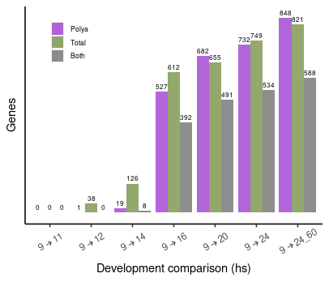

```r
zgaFirstExp_plot
```

## 4.1 Check the overlap between stage-specific genes and those detectd in previous timepoints

```r
stage_index <- c(2:7) # genes detected at stages 14,16,20,24,24_60
unique_genes_list <-  list()

for (i in 1:length(stage_index)) {
 unique_genes_list[[i]] <- setdiff(
 c(firstExp_polya[stage_index[i]] %>% unlist %>% as.character(), firstExp_total[stage_index[i]] %>% unlist() %>% as.character()) %>% unique(),
  c(firstExp_polya[c(1:(stage_index[i]- 1))] %>% unlist %>% as.character(), firstExp_total[c(1:(stage_index[i]-1))] %>% unlist() %>% as.character()) %>% unique()
) %>% unique() %>% length()

}
names(unique_genes_list)  <- c('0-9_12','0-9_13-14','0-9_16','0-9_20','0-9_24','0-9_24-60')

unique_genes_list
```

```
$`0-9_12`
[1] 39

$`0-9_13-14`
[1] 100

$`0-9_16`
[1] 610

$`0-9_20`
[1] 137

$`0-9_24`
[1] 117

$`0-9_24-60`
[1] 307
```

# 5 PLot number of stage-specific zygotic genes per stage

```r
setwd("/drives/ssd1/manuel/phaw/2022_analysis/mzt_analysis")
#Make dataframe to plot
zgaFirstExp_unique <- data.frame(
  stage = c(1,2,3,4,5,6),
  genes = unique_genes_list %>% unlist())

zgaFirstExp_unique_plot <- zgaFirstExp_unique %>%
  ggplot(aes(x=factor(stage),y=genes)) +
  #geom_bar(stat = "identity", position = position_dodge(), alpha = 0.75) +
  geom_line( aes(group=1),colour="darkolivegreen4",alpha=0.5,size=1.3) + #geom_point(shape=23,colour="darkolivegreen4")+
  geom_text(aes(label = genes), fontface = "plain", vjust = -0.45,
            position = position_dodge(.9), size = 3) + ylab("Genes")+ xlab("Development comparison (hs)") +
    scale_x_discrete(labels= c(expression(9 %->% 12),expression(9 %->% 14),expression(9 %->% 16),
                             expression(9 %->% 20),expression(9 %->% 24),expression(9 %->% `24-60`))) +
  scale_y_continuous(expand = c(0,50))+
  theme(legend.title=element_blank(),axis.text.x = element_text(size = 10,angle =30,vjust = 0.65),
        axis.ticks.y=element_blank(), legend.key.size = unit(0.4, 'cm'),
        axis.text.y = element_blank(),legend.position="none",legend.text = element_text(size=6),
        axis.title = element_text(size = 14),panel.background = element_blank(),
        axis.line = element_line(colour = "black"))#+ scale_fill_gradient2(low='red', mid='grey3', high='darkgreen', space='Lab',guide = "none")
zgaFirstExp_unique_plot

tiff("zgaFirstExp_unique_plot.tiff", width = 3, height = 3, units = "in",res = 400,compression = "lzw")
```

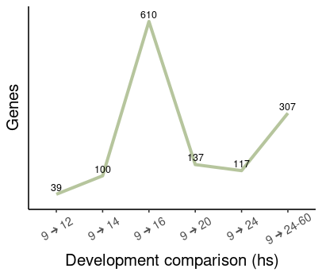

```r
zgaFirstExp_unique_plot
dev.off()
```

# 6 Create dataframe with all annotated genes, adding info if they are zygotic (1) or not (0)

```r
zygoticGenes_FirstExp_df <- exon_polyA_counts %>% rownames_to_column("gene") %>%
  select(gene) %>%
  mutate(zyg_9_11_p = ifelse(gene %in% firstExp_polya[[1]],1,0),
         zyg_9_12_p = ifelse(gene %in% firstExp_polya[[2]],1,0),
         zyg_9_14_p = ifelse(gene %in% firstExp_polya[[3]],1,0),
         zyg_9_16hs_p = ifelse(gene %in% firstExp_polya[[4]],1,0),
         zyg_9_20hs_p = ifelse(gene %in% firstExp_polya[[5]],1,0),
         zyg_9_24hs_p = ifelse(gene %in% firstExp_polya[[6]],1,0),
         zyg_2_24_60hs_p = ifelse(gene %in% firstExp_polya[[7]],1,0),
         zyg_9_11_t = ifelse(gene %in% firstExp_total[[1]],1,0),
         zyg_9_12_t = ifelse(gene %in% firstExp_total[[2]],1,0),
         zyg_9_14_t = ifelse(gene %in% firstExp_total[[3]],1,0),
         zyg_9_16hs_t = ifelse(gene %in% firstExp_total[[4]],1,0),
         zyg_9_20hs_t = ifelse(gene %in% firstExp_total[[5]],1,0),
         zyg_9_24hs_t = ifelse(gene %in% firstExp_total[[6]],1,0),
         zyg_9_24_60hs_t = ifelse(gene %in% firstExp_total[[7]],1,0))
zygoticGenes_FirstExp_df
```

| gene | zyg_9_11_p | zyg_9_12_p | zyg_9_14_p | zyg_9_16hs_p | zyg_9_20hs_p | zyg_9_24hs_p | zyg_2_24_60hs_p | zyg_9_11_t | zyg_9_12_t | zyg_9_14_t | zyg_9_16hs_t | zyg_9_20hs_t | zyg_9_24hs_t | zyg_9_24_60hs_t |
| --- | --- | --- | --- | --- | --- | --- | --- | --- | --- | --- | --- | --- | --- | --- |
| MSTRG.18409 | 0 | 0 | 0 | 0 | 0 | 0 | 0 | 0 | 0 | 0 | 0 | 0 | 0 | 0 |
| MSTRG.18410 | 0 | 0 | 0 | 0 | 0 | 0 | 0 | 0 | 0 | 0 | 0 | 0 | 0 | 0 |
| MSTRG.18412 | 0 | 0 | 0 | 0 | 0 | 0 | 0 | 0 | 0 | 0 | 0 | 0 | 0 | 0 |
| MSTRG.18413 | 0 | 0 | 0 | 0 | 0 | 0 | 0 | 0 | 0 | 0 | 0 | 0 | 0 | 0 |
| MSTRG.18418 | 0 | 0 | 0 | 0 | 0 | 0 | 0 | 0 | 0 | 0 | 0 | 0 | 0 | 0 |
| MSTRG.18420 | 0 | 0 | 0 | 0 | 0 | 0 | 0 | 0 | 0 | 0 | 0 | 0 | 0 | 0 |
| MSTRG.18421 | 0 | 0 | 0 | 0 | 0 | 0 | 0 | 0 | 0 | 0 | 0 | 0 | 0 | 0 |
| MSTRG.18424 | 0 | 0 | 0 | 0 | 0 | 0 | 0 | 0 | 0 | 0 | 0 | 0 | 0 | 0 |
| MSTRG.18428 | 0 | 0 | 0 | 0 | 0 | 0 | 0 | 0 | 0 | 0 | 0 | 0 | 0 | 0 |
| MSTRG.18430 | 0 | 0 | 0 | 0 | 0 | 0 | 0 | 0 | 0 | 0 | 0 | 0 | 0 | 0 |

[output cut: 990 more lines]

```r
write.table(zygoticGenes_FirstExp_df,"zygoticGenes_FirstExp_df.csv",quote = F,sep = ",",row.names = F)
```